# Challenge 2: Spicing things up with ggplot2

Author

Lisette Abundez

For this week’s Challenge, you will have three different options to explore. I’ve arranged these options in terms of their “spiciness,” or the difficulty of completing the task. **You are only required to complete one task, but if you are interested in exploring more than one, feel free!**

This is a great place to let your creativity show! Make sure to indicate what additional touches you added, and provide any online references you used.

# Getting Set-up

Within this document, make sure to specify that your plots are contained in your document (`self-contained: true`) and that your code is visible to the reader (`echo: true`). If there are other formatting specifics you would like to include, feel free to toss those in the YAML, too!

Next, create a setup code chunk to load the packages and read in the `surveys.csv` data file exactly how you did in Lab 2.

```r
library(tidyverse)
library(here)

surveys <- read_csv(here("data", "surveys.csv"))
```

Finally, create another code chunk and paste in your code from Question 14 or Question 15 in Lab 2 – we will be modifying the box plot of weights by species!

**Original Boxplot from Lab 2**

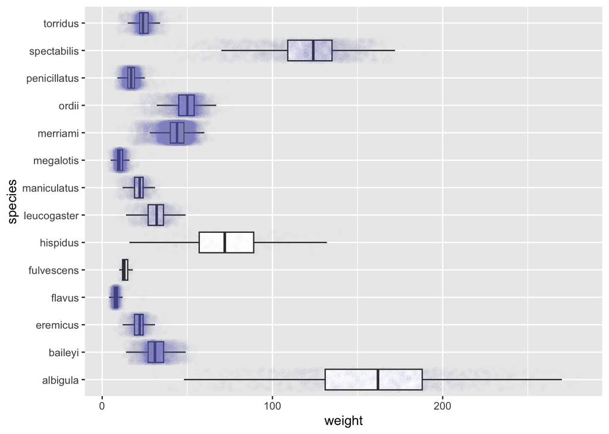

```r
ggplot(data = surveys,
       mapping = aes(x = weight, y = species)) +
  geom_boxplot(outlier.shape = NA) +
  geom_jitter(color = "steelblue", alpha = 0.01)
```

# Medium: Ridge Plots

In Lab 2, you used side-by-side **boxplots** to visualize the distribution of weight within each species of rodent. Boxplots have [substantial flaws](https://www.data-to-viz.com/caveat/boxplot.html), namely that they disguise distributions with multiple modes.

A “superior” alternative is the density plot. However, `ggplot2` does not allow for side-by-side density plots using `geom_density()`. Instead, we will need to make use of the `ggridges` package to create side-by-side density (ridge) plots.

> **For this challenge you are to change your boxplots to ridge plots. You will need to install the `ggridges` package and explore the `geom_density_ridges()` function.**

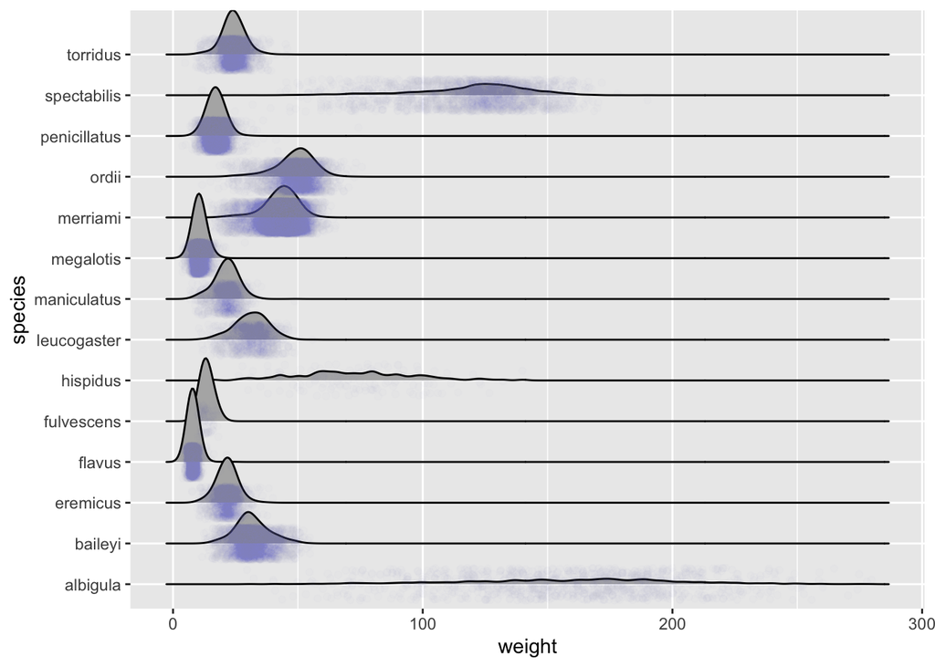

```r
library(ggridges)

ggplot(data = surveys,
       mapping = aes(x = weight, y = species)) +
  geom_density_ridges() +
  geom_jitter(color = "steelblue", alpha = 0.01)
```